[O’Hara on GitHub](https://github.com/oharac)

# Create conservation priorities layers

Compiled on Thu Aug 22 08:04:53 2019 by ohara

```r
library(raster)
source('https://raw.githubusercontent.com/oharac/src/master/R/common.R')

source(here::here('common_fxns.R'))

dir_bd_anx <- '~/git-annex/bd_chi' ### this is on git-annex in home/ohara
dir_cons <- 'layers/cons_priorities'
```

# 1 Summary

*NOTE: This script is identical to `create_cons_priorities_layers.Rmd` except that the 10 km cells are aggregated to 50 x 50 first, to better(?) approximate the cell sizes in Selig et al. 2014.* This is accomplished in the raster reclassification function using `raster::aggregate(fact = 5)`.

Following Selig et al. 2014, estimate conservation priorities based on biodiversity metrics and threats.

- Identify top 10% and bottom 10% of cells based on cumulative impacts.
- Identify top 5% of cells based on species richness and range-rarity species richness, separately within EEZ and ABNJ.
- New: Identify top 5% and bottom 5% of cells based on mean biodiversity risk.
  - when intersecting with species richness, maybe up thresholds on both to 10%?
- New: Identify top 10% and bottom 10% of cells based on trends in CHI.
  - when intersecting with CHI, maybe up thresholds on both to 20%?

Intersect these various layers and see what magic occurs.

# 2 Data Sources

Halpern et al. 2019, O’Hara et al. 2019

# 3 Methods

## 3.1 Identify EEZ and ABNJ regions

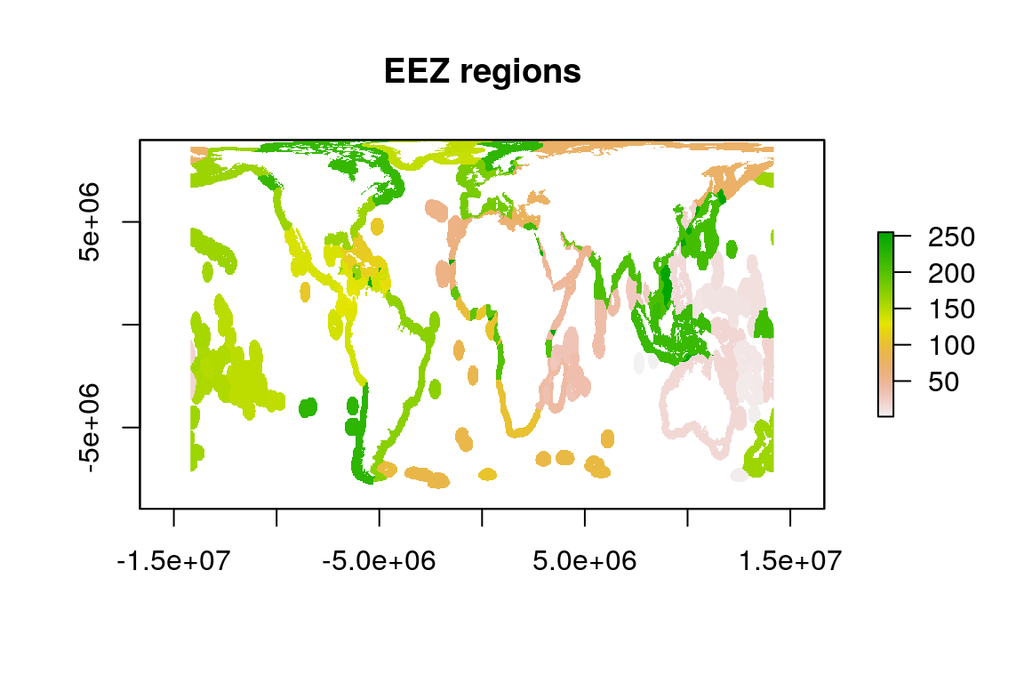

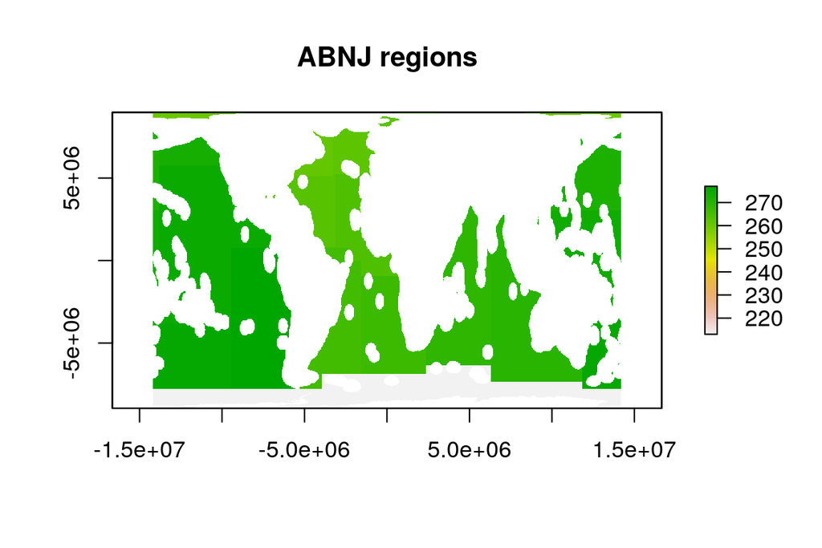

## 3.2 Identify top/bottom 10% and 20% of CHI and dCHI/dt

The function `classify_qtiles()` identifies thresholds separately for EEZ and ABNJ regions, calculates the quantiles for each region separately, then combines into a single raster. EEZ quantiles are positive, ABNJ are negative, just to help keep them separate.

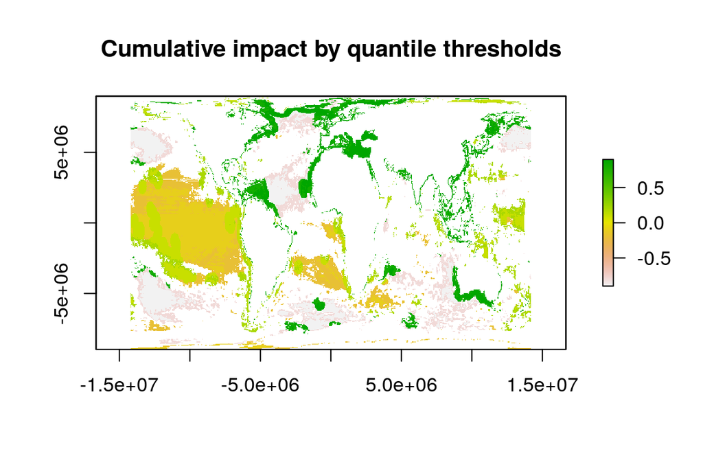

| 0.1 | 0.2 | 0.8 | 0.9 |
| --- | --- | --- | --- |
| 0.5095697 | 0.7175059 | 1.597488 | 1.950149 |

| 0.1 | 0.2 | 0.8 | 0.9 |
| --- | --- | --- | --- |
| 0.3257511 | 0.5420186 | 1.477756 | 1.832701 |

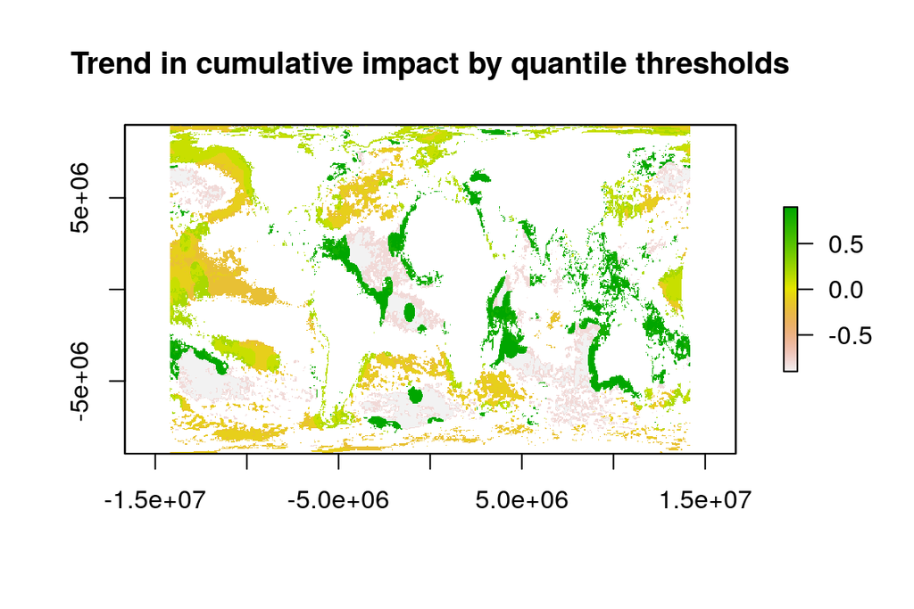

| 0.1 | 0.2 | 0.8 | 0.9 |
| --- | --- | --- | --- |
| -0.0186418 | 0.0023037 | 0.0849422 | 0.1060592 |

| 0.1 | 0.2 | 0.8 | 0.9 |
| --- | --- | --- | --- |
| -0.0115009 | 0.0027952 | 0.0865868 | 0.117033 |

## 3.3 Identify top/bottom 5% and 10% of species richness, range-rarity SR

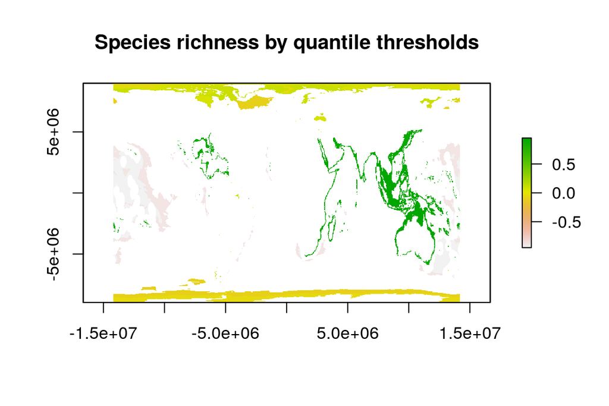

| 0.05 | 0.1 | 0.9 | 0.95 |
| --- | --- | --- | --- |
| 13.26667 | 29.036 | 197.68 | 461.4405 |

| 0.05 | 0.1 | 0.9 | 0.95 |
| --- | --- | --- | --- |
| 26.56 | 39 | 71 | 77.6 |

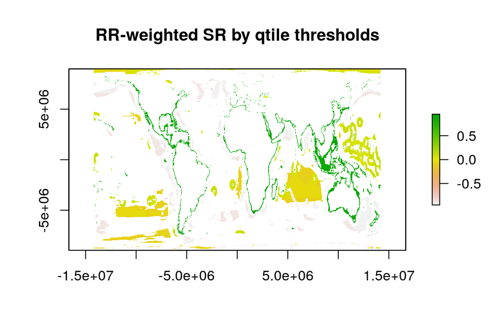

| 0.05 | 0.1 | 0.9 | 0.95 |
| --- | --- | --- | --- |
| 6e-07 | 7e-07 | 0.0001954 | 0.0003622 |

| 0.05 | 0.1 | 0.9 | 0.95 |
| --- | --- | --- | --- |
| 4e-07 | 5e-07 | 1.2e-06 | 1.5e-06 |

## 3.4 Identify top/bottom 5% and 10% of biodiversity risk (unweighted and RR-weighted)

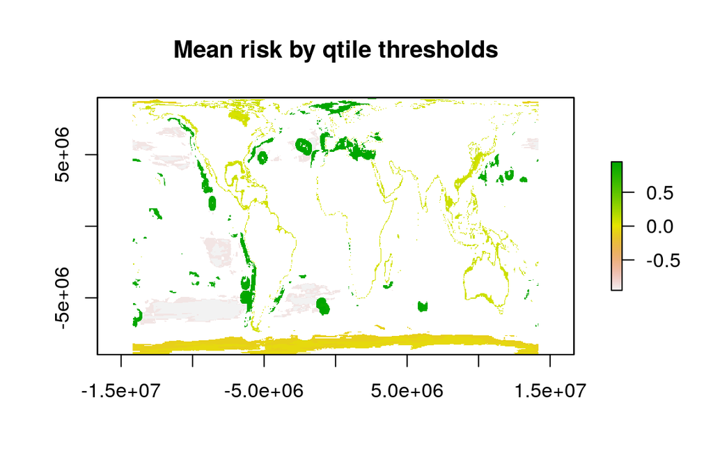

| 0.05 | 0.1 | 0.9 | 0.95 |
| --- | --- | --- | --- |
| 0.0811781 | 0.0996845 | 0.2076163 | 0.2196721 |

| 0.05 | 0.1 | 0.9 | 0.95 |
| --- | --- | --- | --- |
| 0.1065997 | 0.1356028 | 0.2340426 | 0.2417889 |

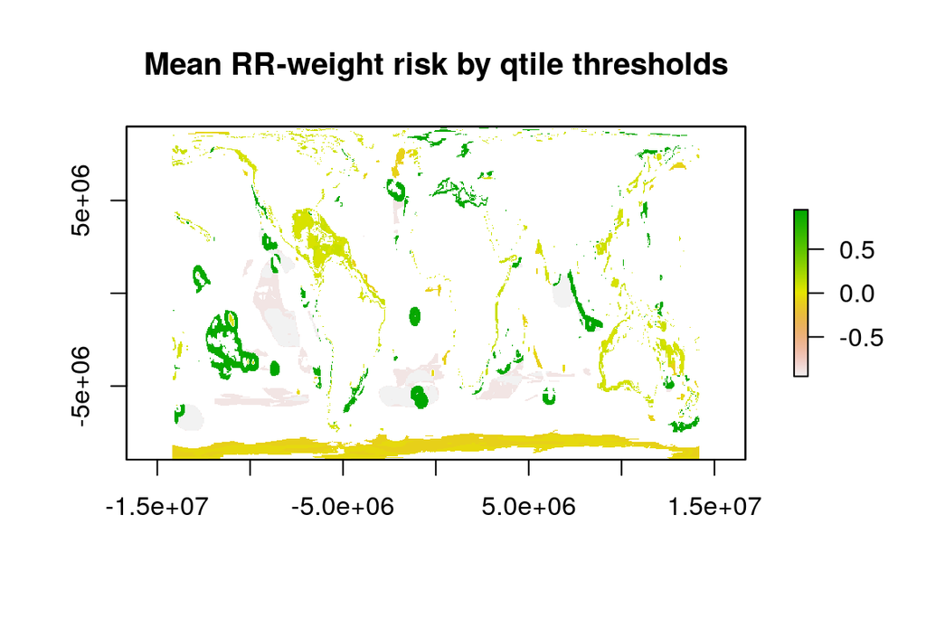

| 0.05 | 0.1 | 0.9 | 0.95 |
| --- | --- | --- | --- |
| 0.0296718 | 0.0447071 | 0.2538 | 0.286472 |

| 0.05 | 0.1 | 0.9 | 0.95 |
| --- | --- | --- | --- |
| 0.0535524 | 0.0781286 | 0.3087298 | 0.3380396 |

## 3.5 Identify top/bottom 5% and 10% of % threatened (unweighted and RR-weighted)

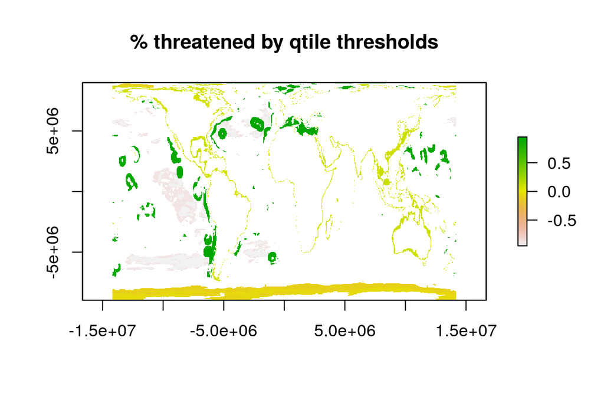

| 0.05 | 0.1 | 0.9 | 0.95 |
| --- | --- | --- | --- |
| 0.1290208 | 0.1608448 | 0.3805052 | 0.4032026 |

| 0.05 | 0.1 | 0.9 | 0.95 |
| --- | --- | --- | --- |
| 0.1556893 | 0.2240624 | 0.436549 | 0.4481733 |

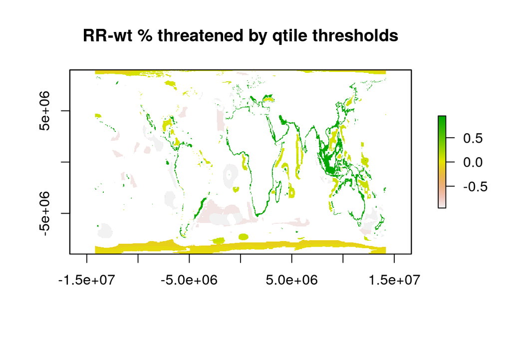

| 0.05 | 0.1 | 0.9 | 0.95 |
| --- | --- | --- | --- |
| 1e-07 | 2e-07 | 2.03e-05 | 4.1e-05 |

| 0.05 | 0.1 | 0.9 | 0.95 |
| --- | --- | --- | --- |
| 0 | 1e-07 | 4e-07 | 6e-07 |